# R Notebook

#Libraries

```r
library(tidyverse)
library(infer)
library(janitor)
```

# Q1 - Load the data again, clean_names(), and re-familiarise yourself with it

```r
ames_houses <- read_csv("ames.csv") %>% clean_names()
```

```r
ames_houses %>%
  skimr::skim()
```

```
-- Data Summary ------------------------
                           Values
Name                       Piped data
Number of rows             2930
Number of columns          82
_______________________
Column type frequency:
  character                43
  numeric                  39
________________________
Group variables            None
```

|  | skim_variable | n_missing | complete_rate | min | max | empty | n_unique | whitespace |
| --- | --- | --- | --- | --- | --- | --- | --- | --- |
| 1 | ms_zoning | 0 | 1.00000000 | 2 | 7 | 0 | 7 | 0 |
| 2 | street | 0 | 1.00000000 | 4 | 4 | 0 | 2 | 0 |
| 3 | alley | 2732 | 0.06757679 | 4 | 4 | 0 | 2 | 0 |
| 4 | lot_shape | 0 | 1.00000000 | 3 | 3 | 0 | 4 | 0 |
| 5 | land_contour | 0 | 1.00000000 | 3 | 3 | 0 | 4 | 0 |
| 6 | utilities | 0 | 1.00000000 | 6 | 6 | 0 | 3 | 0 |
| 7 | lot_config | 0 | 1.00000000 | 3 | 7 | 0 | 5 | 0 |
| 8 | land_slope | 0 | 1.00000000 | 3 | 3 | 0 | 3 | 0 |
| 9 | neighborhood | 0 | 1.00000000 | 5 | 7 | 0 | 28 | 0 |
| 10 | condition_1 | 0 | 1.00000000 | 4 | 6 | 0 | 9 | 0 |

[output cut: 33 more lines]

|  | skim_variable | n_missing | complete_rate | mean | sd | p0 | p25 | p50 | p75 | p100 | hist |
| --- | --- | --- | --- | --- | --- | --- | --- | --- | --- | --- | --- |
| 1 | order | 0 | 1.0000000 | 1465.50000000 | 845.9624696 | 1 | 733.25 | 1465.5 | 2197.75 | 2930 |  |
| 2 | pid | 0 | 1.0000000 | 714464496.98873723 | 188730844.6493901 | 526301100 | 528477022.50 | 535453620.0 | 907181097.50 | 1007100110 |  |
| 3 | ms_sub_class | 0 | 1.0000000 | 57.38737201 | 42.6380246 | 20 | 20.00 | 50.0 | 70.00 | 190 |  |
| 4 | lot_frontage | 490 | 0.8327645 | 69.22459016 | 23.3653350 | 21 | 58.00 | 68.0 | 80.00 | 313 |  |
| 5 | lot_area | 0 | 1.0000000 | 10147.92184300 | 7880.0177594 | 1300 | 7440.25 | 9436.5 | 11555.25 | 215245 |  |
| 6 | overall_qual | 0 | 1.0000000 | 6.09488055 | 1.4110261 | 1 | 5.00 | 6.0 | 7.00 | 10 |  |
| 7 | overall_cond | 0 | 1.0000000 | 5.56313993 | 1.1115366 | 1 | 5.00 | 5.0 | 6.00 | 9 |  |
| 8 | year_built | 0 | 1.0000000 | 1971.35631399 | 30.2453606 | 1872 | 1954.00 | 1973.0 | 2001.00 | 2010 |  |
| 9 | year_remod_add | 0 | 1.0000000 | 1984.26655290 | 20.8602859 | 1950 | 1965.00 | 1993.0 | 2004.00 | 2010 |  |
| 10 | mas_vnr_area | 23 | 0.9921502 | 101.89680083 | 179.1126106 | 0 | 0.00 | 0.0 | 164.00 | 1600 |  |

[output cut: 29 more lines]

# Q2 - Investigate the distribution of lot_area. Is the distribution roughly normal? If not, what problems do you find?

The distribution isn’t normal - the data is positively skewed and there are quite a few outlier houses with very large lot areas. This isn’t very surprising for Iowa since it’s a state with some built-up areas, but also a lot of farms and houses in semi-rural/rural areas that tend to have large lots. This is a bit hard to see on the histogram since the count isn’t very high for the houses with large lots, but it’s easier to see on the box-plot.

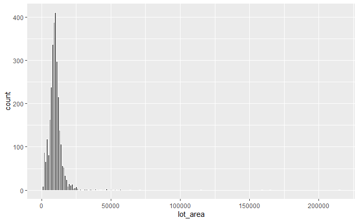

```r
ames_houses %>%
  ggplot(aes(x = lot_area)) +
  geom_histogram(col = "white", binwidth = 1000)
```

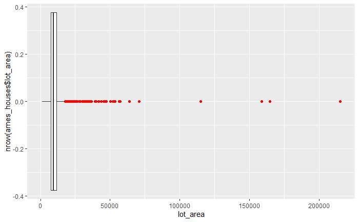

```r
ames_houses %>%
  ggplot(aes(x = lot_area,
             y = nrow(ames_houses$lot_area))) +
  geom_boxplot(outlier.color = "red")
```

```r
shapiro.test(ames_houses$lot_area)
```

```
    Shapiro-Wilk normality test

data:  ames_houses$lot_area
W = 0.4357, p-value < 0.00000000000000022
```

# Q3 - Compute and visualise a bootstrap sampling distribution for the mean(lot_area) of the sold houses.

[figure not shown]

# Q4 - Use your bootstrap distribution to calculate a 95% CI for mean(lot_area), and visualise it on the distribution

[figure not shown]

# Q5 - You would like to know the mean(lot_area) of the sold houses with higher confidence. Calculate the 99% CI for this variable (you can re-use your bootstrap distribution from above). Is it narrower or broader than the 95% CI? Does that make sense?

It is broader and that makes sense because we can expect more of the bootstrap sample means to fall within the 99% CI than the 95% CI. The total data falling outside the 99% CI highlighted on the graph below should only be 0.5% on each side of the shaded area. For the 95% CI, we can expect 2.5% of the data to fall outside each side of the shaded area on the histogram above.

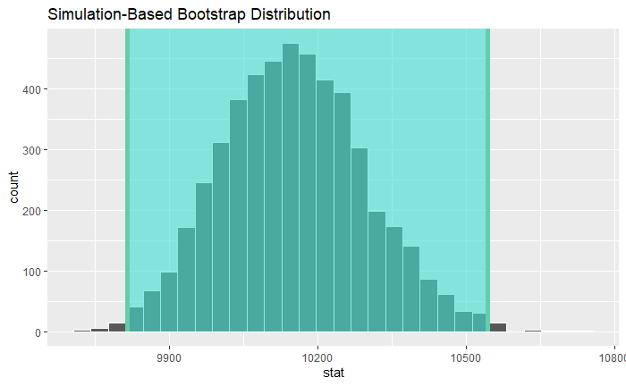

```r
infer_ci_99 <- infer_resample %>%
  get_ci(level = 0.99, type = "percentile")

infer_resample %>%
  visualise(bins = 30) +
  shade_ci(endpoints = infer_ci_99)
```

# Q6 - Calculate the point estimate of the mean(lot_area)

```r
infer_resample %>%
  #ungroup() %>%
  summarise(
    mean_means_lot_area = mean(stat)
  )
```

| mean_means_lot_area |
| --- |
| 10152.28 |